# Lab: Random Effects

Akshay_Gupta_36-600_Lab_07R

Today’s lab will be relatively short, so that you can turn it in and head off to fall break.

## Data

Here we read in the sleep study data from Project 1 and we retain three variables: `cohort` and `term_gpa` as predictors, and `TotalSleepTime` (renamed `sleep`) as the response.

```r
suppressMessages(library(tidyverse))
df        <- read.csv(url("https://www.stat.cmu.edu/~pfreeman/cmu-sleep.csv"))
df$cohort <- factor(df$cohort)
df %>% select(.,cohort,TotalSleepTime,term_gpa) -> df
names(df)[2] <- "sleep"
summary(df)
```

```
##   cohort        sleep          term_gpa
##  lac1:131   Min.   :194.8   Min.   :0.350
##  lac2: 77   1st Qu.:366.9   1st Qu.:3.233
##  nh  :147   Median :400.4   Median :3.556
##  uw1 :140   Mean   :397.3   Mean   :3.450
##  uw2 :139   3rd Qu.:430.1   3rd Qu.:3.810
##             Max.   :587.7   Max.   :4.000
```

Note that in this lab, we are not going to split the data into training and test sets.

## Question 1

Let’s first assume that we regress `sleep` upon `cohort`. Since the cohorts that appear in the study are a randomly selected subset of all possible cohorts, pursuing learning a random effects model is appropriate (as opposed to a one-way ANOVA model). Learn an appropriate model using `lmer()` and pass the output to `summary()`. Display the five intercepts for the five cohorts. (Hint: utilize one of the functions shown in the notes, one specifically used with the Palmer Penguin data.) Last, what is the within-cohort correlation? (This last part involves extracting numbers from the `summary()` output and “doing math” as opposed to making further function calls.) Is this a weak, medium, or strong correlation? (Use the internet to make that judgement. Note that no two tables mapping correlation coefficients to adjectives seem to match.)

```r
suppressMessages(library(lme4))  # uncomment once the library is installed
# FILL ME IN WITH CODE
lm.out <- lmer(sleep~(1|cohort), data=df)
summary(lm.out)
```

```
## Linear mixed model fit by REML ['lmerMod']
## Formula: sleep ~ (1 | cohort)
##    Data: df
##
## REML criterion at convergence: 6747.1
##
## Scaled residuals:
##     Min      1Q  Median      3Q     Max
## -4.3441 -0.6160  0.0175  0.6454  3.7001
##
## Random effects:
##  Groups   Name        Variance Std.Dev.
##  cohort   (Intercept)  205.7   14.34
##  Residual             2429.7   49.29
## Number of obs: 634, groups:  cohort, 5
##
## Fixed effects:
##             Estimate Std. Error t value
## (Intercept)   395.93       6.72   58.91
```

```r
coef(lm.out)$cohort
```

```
##      (Intercept)
## lac1    391.9559
## lac2    381.1778
## nh      385.9503
## uw1     411.6616
## uw2     408.9144
```

```
The correlation is weak (0.07).
```

## Question 2

Now let’s look at `term_gpa`. Learn a simple linear regression model that has `sleep` as the response variable and `term_gpa` as the predictor variable, and overlay the model on a plot of `sleep` versus `term_gpa`. Also, determine the AIC value for the model.

```r
# FILL ME IN WITH CODE
lm <- lm(sleep ~ term_gpa, data = df)
AIC_lm <- AIC(lm)
print(AIC_lm)
```

```
## [1] 6759.875
```

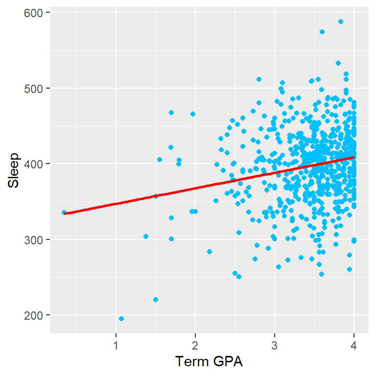

```r
#summary(lm)

ggplot(df, aes(x = term_gpa, y = sleep)) +  geom_point(col="deepskyblue") +
  geom_smooth(method = "lm", se = FALSE, color = "red") +  # Regression line
  labs(x = "Term GPA",y = "Sleep")
```

## Question 3

Now implement a mixed effects model with `term_gpa` as the fixed effect and `cohort` as the random effect, with random intercepts (but same slopes). Output the linear model coefficients for each cohort. (Mentally confirm that indeed, the intercepts are different but the slopes are the same.) And, as you did in Q2, record the AIC value.

No plot is necessary, for now.

```r
# FILL ME IN WITH CODE
lm.out3 <- lmer(sleep~term_gpa+(1|cohort), data=df)
summary(lm.out3)
```

```
## Linear mixed model fit by REML ['lmerMod']
## Formula: sleep ~ term_gpa + (1 | cohort)
##    Data: df
##
## REML criterion at convergence: 6703.9
##
## Scaled residuals:
##     Min      1Q  Median      3Q     Max
## -3.3027 -0.6417  0.0008  0.6684  3.6546
##
## Random effects:
##  Groups   Name        Variance Std.Dev.
##  cohort   (Intercept)  262.2   16.19
##  Residual             2285.5   47.81
## Number of obs: 634, groups:  cohort, 5
##
## Fixed effects:
##             Estimate Std. Error t value
## (Intercept)  309.790     15.557  19.914
## term_gpa      24.971      3.953   6.317
##
## Correlation of Fixed Effects:
##          (Intr)
## term_gpa -0.876
```

```r
AIC_lm.out3 <- AIC(lm.out3)
print(AIC_lm.out3)
```

```
## [1] 6711.948
```

## Question 4

Repeat Q3, but now have random slopes with the same intercept.

```r
# FILL ME IN WITH CODE
lm.out4 <- lmer(sleep~term_gpa+(0+term_gpa|cohort), data=df)
summary(lm.out4)
```

```
## Linear mixed model fit by REML ['lmerMod']
## Formula: sleep ~ term_gpa + (0 + term_gpa | cohort)
##    Data: df
##
## REML criterion at convergence: 6705.9
##
## Scaled residuals:
##     Min      1Q  Median      3Q     Max
## -3.1467 -0.6384  0.0161  0.6801  3.6836
##
## Random effects:
##  Groups   Name     Variance Std.Dev.
##  cohort   term_gpa   20.05   4.478
##  Residual          2293.67  47.892
## Number of obs: 634, groups:  cohort, 5
##
## Fixed effects:
##             Estimate Std. Error t value
## (Intercept)  315.424     13.575  23.236
## term_gpa      23.436      4.387   5.342
##
## Correlation of Fixed Effects:
##          (Intr)
## term_gpa -0.881
```

```r
AIC_lm.out4 <- AIC(lm.out4)
print(AIC_lm.out4)
```

```
## [1] 6713.929
```

## Question 5

Repeat Q3, but now have random slopes *and* intercepts.

```r
# FILL ME IN WITH CODE
lm.out5 <- lmer(sleep~term_gpa+(term_gpa|cohort), data=df)
summary(lm.out5)
```

```
## Linear mixed model fit by REML ['lmerMod']
## Formula: sleep ~ term_gpa + (term_gpa | cohort)
##    Data: df
##
## REML criterion at convergence: 6702
##
## Scaled residuals:
##     Min      1Q  Median      3Q     Max
## -3.3004 -0.6271 -0.0078  0.6573  3.6963
##
## Random effects:
##  Groups   Name        Variance Std.Dev. Corr
##  cohort   (Intercept) 2668.7   51.66
##           term_gpa     128.4   11.33    -0.97
##  Residual             2267.2   47.62
## Number of obs: 634, groups:  cohort, 5
##
## Fixed effects:
##             Estimate Std. Error t value
## (Intercept)  296.802     27.484   10.80
## term_gpa      28.456      6.602    4.31
##
## Correlation of Fixed Effects:
##          (Intr)
## term_gpa -0.967
```

```r
AIC_lm.out5 <- AIC(lm.out5)
print(AIC_lm.out5)
```

```
## [1] 6713.963
```

## Question 6

Select the best model from among those in Q2-Q5 (i.e., the one with the lowest AIC value). Plot the data again, and overlay the best model…note that this may require you to make five separate calls to `geom_abline()`. Note that to access the slopes and intercepts, you would use, e.g.,

```
coefs <- coef(lmer.out)$cohort
coefs[1,1] # first row, first column -- intercept of first cohort
coefs[3,2] # third row, second column -- slope of third cohort
etc.
```

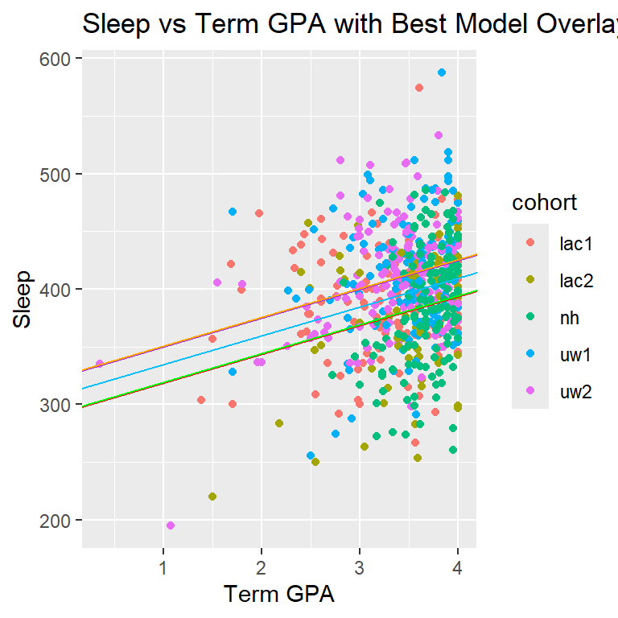

```r
# FILL ME IN WITH CODE
coefs <- coef(lm.out3)$cohort # Using model in Question 3

ggplot(df, aes(x=term_gpa, y=sleep, color=cohort)) +
  geom_point() + labs(title="Sleep vs Term GPA with Best Model Overlay", x="Term GPA", y="Sleep") +
  geom_abline(slope=coefs[1, 2], intercept=coefs[1, 1], color="deepskyblue") +  # First cohort
  geom_abline(slope=coefs[2, 2], intercept=coefs[2, 1], color="red") +   # Second cohort
  geom_abline(slope=coefs[3, 2], intercept=coefs[3, 1], color="green") + # Third cohort
  geom_abline(slope=coefs[4, 2], intercept=coefs[4, 1], color="purple") + # Fourth cohort
  geom_abline(slope=coefs[5, 2], intercept=coefs[5, 1], color="orange") # Fifth cohort
```